# **R Code sample part 2**

Ivan Baksic

## 3) Downloading melanoma single based substitution mutation type (SKCA-BR) and counting overlaps

In this part I downloaded melanoma SNP data, performed filtration and counted overlaps with each reference genome window created in part 1. Finally, I merged mentioned melanoma SNP window counts with mark counts created in part 2 for every biosample.

Packages used

```r
library(dplyr)
library(tidyr)
library(data.table)
library(GenomicRanges)
library(ggplot2)
```

From ICGC DCC Data Portal Release 28 I downloaded melanoma mutations SKCA-BR data set and filtered it.  
Here, I filtered SKCA-BR subset as an example:

```r
SKCA_BR_sample <- fread("https://raw.githubusercontent.com/Baksic-Ivan/R_code_sample-Cancer_Cell-of-Origin_Determination/main/simple_somatic_mutation.open.SKCA-BR_sample.csv")

#filter Whole Genome Sequencing strategy and single base substitution mutation type
SKCA_BR_sample_WGS_SNP <- filter(SKCA_BR_sample,
                                 sequencing_strategy == "WGS",
                                 mutation_type == "single base substitution") %>%

  # create columns for GRanges
  mutate(.,
         chromosome = paste("chr", chromosome, sep = ""),
         start = chromosome_start,
         end = chromosome_end) %>%

  #select only relevant columns
  select(.,
         chromosome,
         start,
         end) %>%
  GRanges(.)

SKCA_BR_sample_WGS_SNP
```

```
## GRanges object with 36100 ranges and 0 metadata columns:
##           seqnames    ranges strand
##              <Rle> <IRanges>  <Rle>
##       [1]     chr8 109768883      *
##       [2]     chr4   3643290      *
##       [3]     chr8   7655500      *
##       [4]     chr8   7655500      *
##       [5]    chr10   2126670      *
##       ...      ...       ...    ...
##   [36096]     chr7  31773063      *
##   [36097]     chr7  32104683      *
##   [36098]     chr7  32104683      *
##   [36099]     chr7  32104683      *
##   [36100]     chr7  32104683      *
##   -------
##   seqinfo: 24 sequences from an unspecified genome; no seqlengths
```

Filtering whole SKCA-BR data set results in the following:

```r
SKCA_BR_full_WGS_SNP <- readRDS(url("https://github.com/Baksic-Ivan/R_code_sample-Cancer_Cell-of-Origin_Determination/raw/main/SKCA_BR_full_WGS_SNP_no_mcols.RDS"))
SKCA_BR_full_WGS_SNP
```

```
## GRanges object with 19961139 ranges and 0 metadata columns:
##              seqnames    ranges strand
##                 <Rle> <IRanges>  <Rle>
##          [1]     chr8 109768883      *
##          [2]     chr4   3643290      *
##          [3]     chr8   7655500      *
##          [4]     chr8   7655500      *
##          [5]    chr10   2126670      *
##          ...      ...       ...    ...
##   [19961135]    chr12  11219004      *
##   [19961136]    chr12  11219004      *
##   [19961137]    chr12  11219004      *
##   [19961138]    chr12  11219004      *
##   [19961139]    chr12  11219004      *
##   -------
##   seqinfo: 24 sequences from an unspecified genome; no seqlengths
```

I counted overlaps between filtered dataset and reference genome windows and created count boxplot.

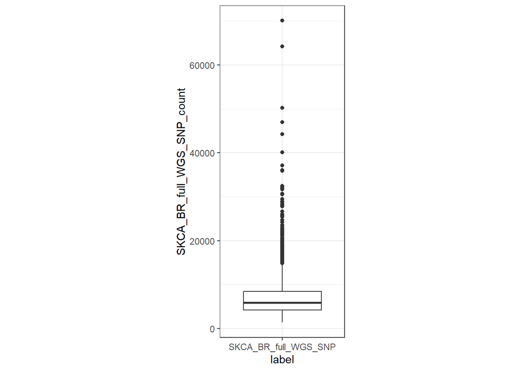

```r
final_reference_hg19_2128 <- readRDS(url("https://github.com/Baksic-Ivan/R_code_sample-Cancer_Cell-of-Origin_Determination/raw/main/final_reference_hg19_2128.RDS"))

SKCA_BR_full_WGS_SNP_count <- countOverlaps(final_reference_hg19_2128, SKCA_BR_full_WGS_SNP)

data.frame(SKCA_BR_full_WGS_SNP_count) %>%
  mutate(., label = "SKCA_BR_full_WGS_SNP") %>%
  ggplot(aes(x = label, y = SKCA_BR_full_WGS_SNP_count)) +
  geom_boxplot() +
  theme_bw() +
  theme(aspect.ratio=8/3)
```

From the boxplot I noticed that there many data outliers. In my thesis I have demonstrated that excluding outliers can significantly improve results so I removed outliers in this example.  
I added melanoma SNP data to chromatin mark data and filtered out outliers.

```r
all_markers_ranges_count_template_final <- read.csv("https://raw.githubusercontent.com/Baksic-Ivan/R_code_sample-Cancer_Cell-of-Origin_Determination/main/all_markers_ranges_count_template_final.csv")

# create nested list with biosamples as names
all_markers_ranges_count_template_final <- split(all_markers_ranges_count_template_final, all_markers_ranges_count_template_final$ind)

SKCA_BR_full_WGS_SNP_table_no_out <- lapply(all_markers_ranges_count_template_final,
                                            function (x) {
                                              # add mutation window counts
                                              mutate(x, mutation = SKCA_BR_full_WGS_SNP_count) %>%
                                                select(., -c(ind, window_id)) %>%
                                                # remove all colums with NA
                                                select_if(.,~any(!is.na(.))) %>%
                                                # filter out outlier mutation count observations
                                                filter(., mutation <= IQR(SKCA_BR_full_WGS_SNP_count)*1.5 + quantile(SKCA_BR_full_WGS_SNP_count, 0.75))
                                              })

head(SKCA_BR_full_WGS_SNP_table_no_out[[1]])
```

```
##   H3K27ac H3K9me3 H3K4me3 H3K27me3 mutation
## 1     706    1662    1422      486    12801
## 2     190    2248     322      504    12333
## 3      78    2400     198      348     5516
## 4      54    2868      20       22     4052
## 5     392    1198     542      484     7222
## 6     486    1084     322      490     4172
```

This reduced the number of windows to 1993.

```r
dim(SKCA_BR_full_WGS_SNP_table_no_out[[1]])
```

```
## [1] 1993    5
```

I used created list of dataframes to built machine learning models in part 4.